# Inequalities of the US Prison System

Hillary Chen

2022-11-01

## Abstract

Across the history of the United States, the federal and state prison systems have given rise to several inequalities in their populations. This report examines several variables such as race and the ratio of POC to white prisoners, the growth of different prison populations over the years, and proportions of female imprisonment by state. In general, it was found that the highest ratios of POC to white prisoners along with the highest proportions of female imprisonment occurred in mostly Southern states, and that there has been a significantly steep increase in prison populations on both a national and state scale.

## Introduction

One of the most glaring examples of racism in America lies within its prison system. One of the main contributors is the systematic prejudices in our social and political realms, which lead to a disproportionate number of people of color being wrongfully arrested or over-policed. The Vera Institute, whose research is referenced in this report, aims to draw attention to this problem and “end the overcriminalization and mass incarceration of people of color, immigrants, and people experiencing poverty”. The information gleaned from these populations, in other words the indirect stakeholders, can be used by researchers, data analysts, and political activists to work towards change, making them the direct stakeholders. Using the Vera Institute’s data, this report aims to expose patterns of inequality through the questions, “What county has the highest ratio of prisoners of color to white prisoners*?“,”What county has the lowest ratio of prisoners of color to white prisoners?” and “What was the average ratio of prisoners of color to white prisoners in King County, WA from 1970 to 2018?”.

## Data Summary

The highest ratio of prisoners/people of color (POC) to white prisoners is 87.8571429 in Webb County, TX, in 2011. Such a high relative ratio points to a continuation of strong historical patterns of inequality targeted at POC in that area and could suggest similarly high rates in the surrounding regions. On the other hand, the lowest ratio of POC to white prisoners is 0.0151134 in Laurel County, KY, in 2013. A low ratio like the one found here may be attributed to a community more accepting of POC, or possibly just a low population of POC in the area to begin with. In my home county of King County, WA, the average ratio of POC to white prisoners across 49 years (1970-2018) was revealed to be 0.8400179. Falling well below the highest ratio and a bit above the lowest, King County, WA does not appear to be an area with historically extreme prejudices (at least in the past half-decade), so this could again point to weaker patterns of inequality or a smaller starting population of POC.

## Growth of the U.S. Prison Population

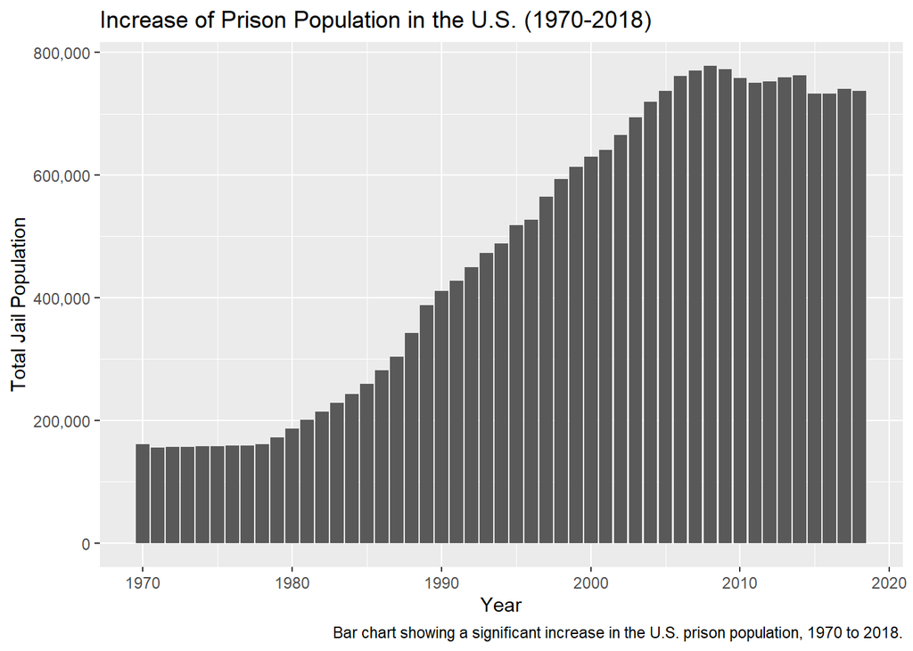

This bar chart can be used to answer the question, “How has the total U.S. prison population fluctuated from 1970 to 2018?” Looking at the graph, we can see that the population has more than doubled over the 49-year period, with the smallest population being 1.5567898^{5} around 1971 and the largest population falling at 7.7820076^{5} around 2008.

## Growth of Jail Population by State

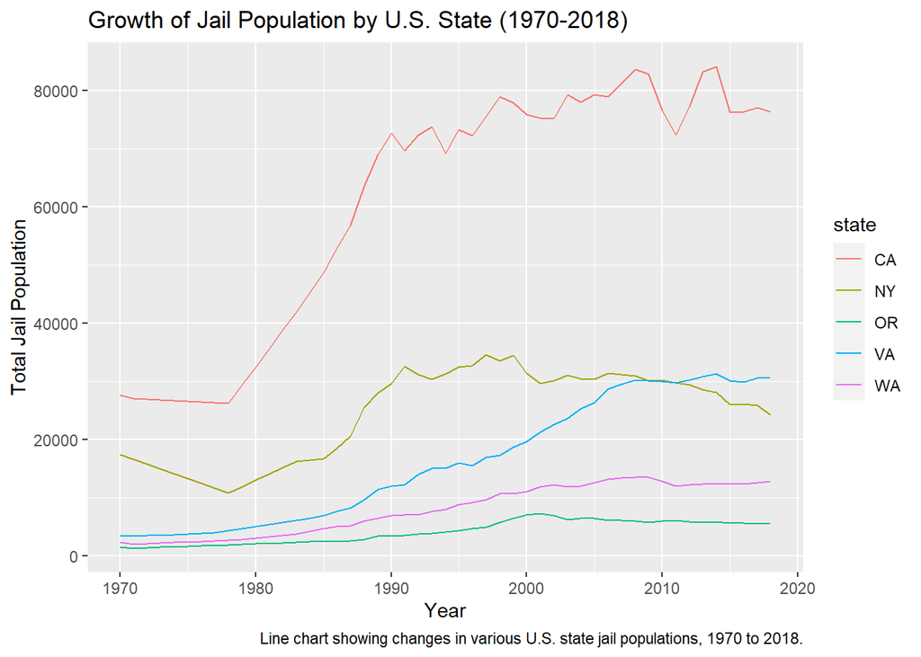

## Imprisonment Rates and Total Prison Populations in WA

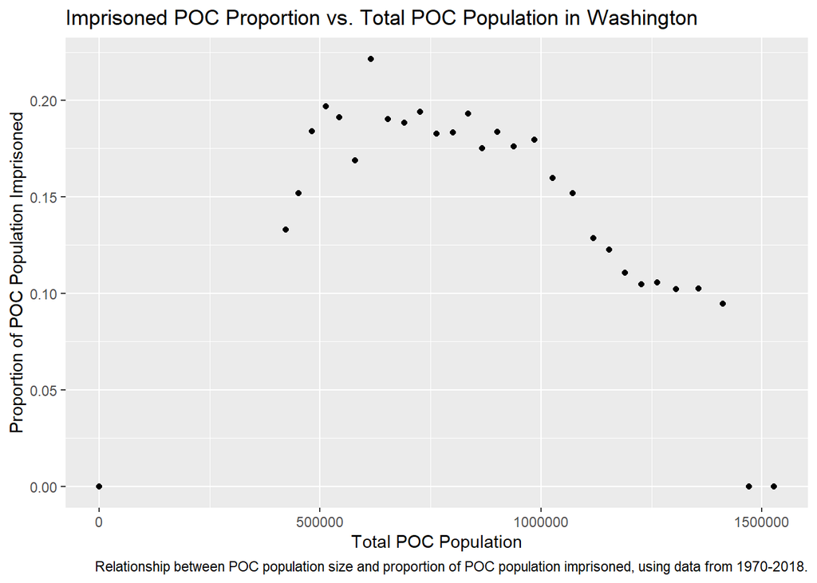

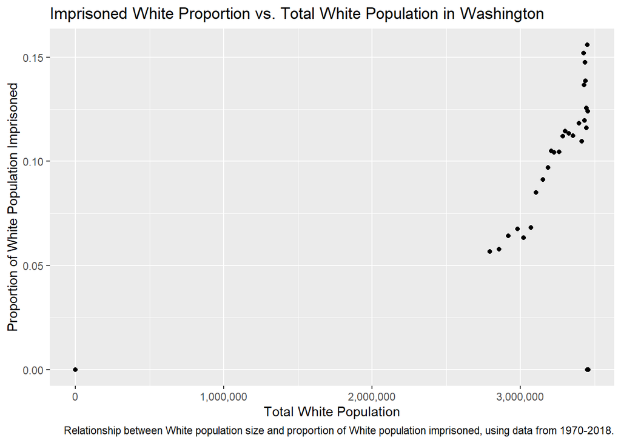

## Geograpic Distribution of Female Imprisonment Rate Variance

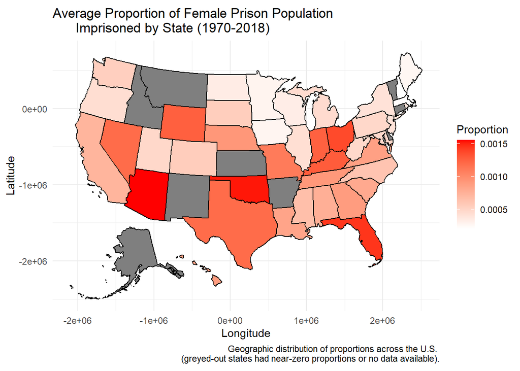